# Risk Factor Analysis

## Outcome Variable

**Outcome Variable:** stunted

## Predictor Variables

**Intervention Variable:** predfeed36

**Adjustment Set:**

- arm
- sex
- month
- brthmon
- W_mage
- meducyrs
- feducyrs
- hhwealth_quart
- hfoodsec
- W_mhtcm
- W_mwtkg
- W_mbmi
- vagbrth
- W_gagebrth
- W_birthwt
- W_birthlen
- W_nrooms
- W_nchldlt5
- W_parity
- impfloor
- impsan
- safeh20
- delta_W_mage
- delta_meducyrs
- delta_feducyrs
- delta_hhwealth_quart
- delta_hfoodsec
- delta_W_mhtcm
- delta_W_mwtkg
- delta_W_mbmi
- delta_vagbrth
- delta_W_gagebrth
- delta_W_birthwt
- delta_W_birthlen
- delta_W_nrooms
- delta_W_nchldlt5
- delta_W_parity
- delta_impfloor
- delta_impsan
- delta_safeh20

## Stratifying Variables

The analysis was stratified on these variable(s):

- agecat
- studyid
- country

## Data Summary

| agecat | studyid | country | predfeed36 | stunted | n_cell | n |
| --- | --- | --- | --- | --- | --- | --- |
| Birth | ki0047075b-MAL-ED | BANGLADESH | 1 | 0 | 62 | 221 |
| Birth | ki0047075b-MAL-ED | BANGLADESH | 1 | 1 | 10 | 221 |
| Birth | ki0047075b-MAL-ED | BANGLADESH | 0 | 0 | 119 | 221 |
| Birth | ki0047075b-MAL-ED | BANGLADESH | 0 | 1 | 30 | 221 |
| Birth | ki0047075b-MAL-ED | BRAZIL | 1 | 0 | 6 | 65 |
| Birth | ki0047075b-MAL-ED | BRAZIL | 1 | 1 | 2 | 65 |
| Birth | ki0047075b-MAL-ED | BRAZIL | 0 | 0 | 50 | 65 |
| Birth | ki0047075b-MAL-ED | BRAZIL | 0 | 1 | 7 | 65 |
| Birth | ki0047075b-MAL-ED | INDIA | 1 | 0 | 2 | 42 |
| Birth | ki0047075b-MAL-ED | INDIA | 1 | 1 | 2 | 42 |
| Birth | ki0047075b-MAL-ED | INDIA | 0 | 0 | 31 | 42 |
| Birth | ki0047075b-MAL-ED | INDIA | 0 | 1 | 7 | 42 |
| Birth | ki0047075b-MAL-ED | NEPAL | 1 | 0 | 0 | 26 |
| Birth | ki0047075b-MAL-ED | NEPAL | 1 | 1 | 1 | 26 |
| Birth | ki0047075b-MAL-ED | NEPAL | 0 | 0 | 24 | 26 |
| Birth | ki0047075b-MAL-ED | NEPAL | 0 | 1 | 1 | 26 |
| Birth | ki0047075b-MAL-ED | PERU | 1 | 0 | 52 | 223 |
| Birth | ki0047075b-MAL-ED | PERU | 1 | 1 | 6 | 223 |
| Birth | ki0047075b-MAL-ED | PERU | 0 | 0 | 145 | 223 |
| Birth | ki0047075b-MAL-ED | PERU | 0 | 1 | 20 | 223 |
| Birth | ki0047075b-MAL-ED | SOUTH AFRICA | 1 | 0 | 2 | 105 |
| Birth | ki0047075b-MAL-ED | SOUTH AFRICA | 1 | 1 | 0 | 105 |
| Birth | ki0047075b-MAL-ED | SOUTH AFRICA | 0 | 0 | 94 | 105 |
| Birth | ki0047075b-MAL-ED | SOUTH AFRICA | 0 | 1 | 9 | 105 |
| Birth | ki0047075b-MAL-ED | TANZANIA, UNITED REPUBLIC OF | 1 | 0 | 0 | 119 |
| Birth | ki0047075b-MAL-ED | TANZANIA, UNITED REPUBLIC OF | 1 | 1 | 0 | 119 |
| Birth | ki0047075b-MAL-ED | TANZANIA, UNITED REPUBLIC OF | 0 | 0 | 98 | 119 |
| Birth | ki0047075b-MAL-ED | TANZANIA, UNITED REPUBLIC OF | 0 | 1 | 21 | 119 |
| Birth | ki1000109-EE | PAKISTAN | 1 | 0 | 2 | 7 |
| Birth | ki1000109-EE | PAKISTAN | 1 | 1 | 1 | 7 |

[output cut: 114 more lines]

The following strata were considered:

- agecat: 24 months, studyid: ki0047075b-MAL-ED, country: BANGLADESH
- agecat: 24 months, studyid: ki0047075b-MAL-ED, country: BRAZIL
- agecat: 24 months, studyid: ki0047075b-MAL-ED, country: INDIA
- agecat: 24 months, studyid: ki0047075b-MAL-ED, country: NEPAL
- agecat: 24 months, studyid: ki0047075b-MAL-ED, country: PERU
- agecat: 24 months, studyid: ki0047075b-MAL-ED, country: SOUTH AFRICA
- agecat: 24 months, studyid: ki0047075b-MAL-ED, country: TANZANIA, UNITED REPUBLIC OF
- agecat: 24 months, studyid: ki1000109-EE, country: PAKISTAN
- agecat: 24 months, studyid: ki1113344-GMS-Nepal, country: NEPAL
- agecat: 24 months, studyid: ki1148112-LCNI-5, country: MALAWI
- agecat: 24 months, studyid: kiGH5241-JiVitA-3, country: BANGLADESH
- agecat: 24 months, studyid: kiGH5241-JiVitA-4, country: BANGLADESH
- agecat: 6 months, studyid: ki0047075b-MAL-ED, country: BANGLADESH
- agecat: 6 months, studyid: ki0047075b-MAL-ED, country: BRAZIL
- agecat: 6 months, studyid: ki0047075b-MAL-ED, country: INDIA
- agecat: 6 months, studyid: ki0047075b-MAL-ED, country: NEPAL
- agecat: 6 months, studyid: ki0047075b-MAL-ED, country: PERU
- agecat: 6 months, studyid: ki0047075b-MAL-ED, country: SOUTH AFRICA
- agecat: 6 months, studyid: ki0047075b-MAL-ED, country: TANZANIA, UNITED REPUBLIC OF
- agecat: 6 months, studyid: ki1000109-EE, country: PAKISTAN
- agecat: 6 months, studyid: ki1000304b-SAS-FoodSuppl, country: INDIA
- agecat: 6 months, studyid: ki1113344-GMS-Nepal, country: NEPAL
- agecat: 6 months, studyid: ki1148112-LCNI-5, country: MALAWI
- agecat: 6 months, studyid: kiGH5241-JiVitA-3, country: BANGLADESH
- agecat: 6 months, studyid: kiGH5241-JiVitA-4, country: BANGLADESH
- agecat: Birth, studyid: ki0047075b-MAL-ED, country: BANGLADESH
- agecat: Birth, studyid: ki0047075b-MAL-ED, country: BRAZIL
- agecat: Birth, studyid: ki0047075b-MAL-ED, country: INDIA
- agecat: Birth, studyid: ki0047075b-MAL-ED, country: NEPAL
- agecat: Birth, studyid: ki0047075b-MAL-ED, country: PERU
- agecat: Birth, studyid: ki0047075b-MAL-ED, country: SOUTH AFRICA
- agecat: Birth, studyid: ki0047075b-MAL-ED, country: TANZANIA, UNITED REPUBLIC OF
- agecat: Birth, studyid: ki1000109-EE, country: PAKISTAN
- agecat: Birth, studyid: ki1113344-GMS-Nepal, country: NEPAL
- agecat: Birth, studyid: kiGH5241-JiVitA-3, country: BANGLADESH
- agecat: Birth, studyid: kiGH5241-JiVitA-4, country: BANGLADESH

### Dropped Strata

Some strata were dropped due to rare outcomes:

- agecat: Birth, studyid: ki0047075b-MAL-ED, country: BRAZIL
- agecat: Birth, studyid: ki0047075b-MAL-ED, country: INDIA
- agecat: Birth, studyid: ki0047075b-MAL-ED, country: NEPAL
- agecat: Birth, studyid: ki0047075b-MAL-ED, country: SOUTH AFRICA
- agecat: Birth, studyid: ki0047075b-MAL-ED, country: TANZANIA, UNITED REPUBLIC OF
- agecat: Birth, studyid: ki1000109-EE, country: PAKISTAN
- agecat: 6 months, studyid: ki0047075b-MAL-ED, country: BRAZIL
- agecat: 6 months, studyid: ki0047075b-MAL-ED, country: INDIA
- agecat: 6 months, studyid: ki0047075b-MAL-ED, country: NEPAL
- agecat: 6 months, studyid: ki0047075b-MAL-ED, country: SOUTH AFRICA
- agecat: 6 months, studyid: ki0047075b-MAL-ED, country: TANZANIA, UNITED REPUBLIC OF
- agecat: 6 months, studyid: ki1000109-EE, country: PAKISTAN
- agecat: 6 months, studyid: ki1000304b-SAS-FoodSuppl, country: INDIA
- agecat: 24 months, studyid: ki0047075b-MAL-ED, country: BRAZIL
- agecat: 24 months, studyid: ki0047075b-MAL-ED, country: NEPAL
- agecat: 24 months, studyid: ki0047075b-MAL-ED, country: SOUTH AFRICA
- agecat: 24 months, studyid: ki0047075b-MAL-ED, country: TANZANIA, UNITED REPUBLIC OF
- agecat: 24 months, studyid: ki1000109-EE, country: PAKISTAN

## Methods Detail

We’re interested in the causal parameters $E[Y_a]$ for all values of $a \in \mathcal{A}$. These parameters represent the mean outcome if, possibly contrary to fact, we intervened to set all units to have $A=a$. Under the randomization and positivity assumptions, these are identified by the statistical parameters $\psi_a=E_W[E_{Y|A,W}(Y|A=a,W)]$. In addition, we’re interested in the mean of $Y$, $E[Y]$ under no intervention (the observed mean). We will estimate these parameters by using SuperLearner to fit the relevant likelihood factors – $E_{Y|A,W}(Y|A=a,W)$ and $p(A=a|W)$, and then updating our likelihood fit using a joint TMLE.

For unadjusted analyses ($W=\{\}$), initial likelihoods were estimated using Lrnr_glm to estimate the simple $E(Y|A)$ and Lrnr_mean to estimate $p(A)$. For adjusted analyses, a small library containing Lrnr_glmnet, Lrnr_xgboost, and Lrnr_mean was used.

Having estimated these parameters, we will then use the delta method to estimate relative risks and attributable risks relative to a prespecified baseline level of $A$.

# Results Detail

## Results Plots

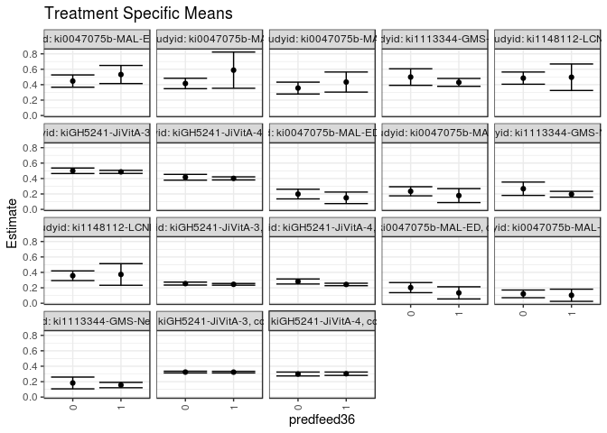

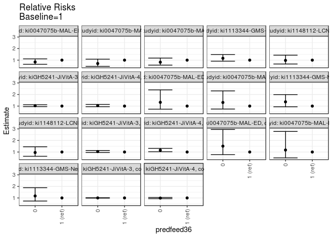

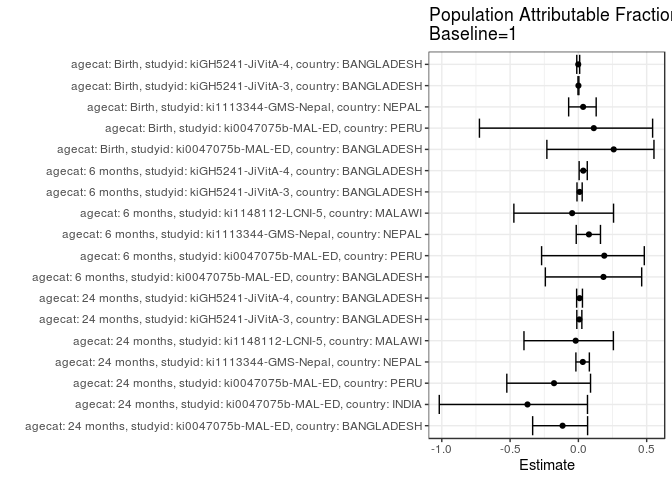

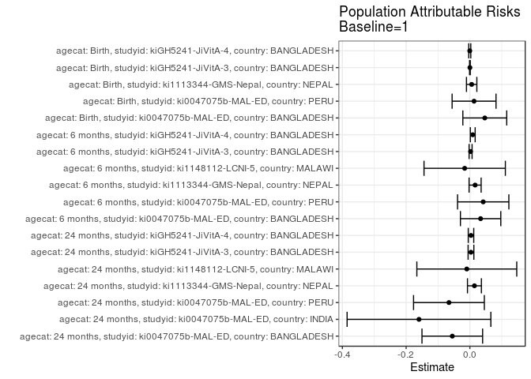

## Results Table

### Parameter: TSM

| agecat | studyid | country | intervention_level | baseline_level | estimate | ci_lower | ci_upper |
| --- | --- | --- | --- | --- | --- | --- | --- |
| Birth | ki0047075b-MAL-ED | BANGLADESH | 1 | NA | 0.1342017 | 0.0553754 | 0.2130280 |
| Birth | ki0047075b-MAL-ED | BANGLADESH | 0 | NA | 0.2023378 | 0.1369504 | 0.2677252 |
| Birth | ki0047075b-MAL-ED | PERU | 1 | NA | 0.1034483 | 0.0248959 | 0.1820007 |
| Birth | ki0047075b-MAL-ED | PERU | 0 | NA | 0.1212121 | 0.0713010 | 0.1711232 |
| Birth | ki1113344-GMS-Nepal | NEPAL | 1 | NA | 0.1559814 | 0.1212666 | 0.1906962 |
| Birth | ki1113344-GMS-Nepal | NEPAL | 0 | NA | 0.1830130 | 0.1065793 | 0.2594468 |
| Birth | kiGH5241-JiVitA-3 | BANGLADESH | 1 | NA | 0.3233439 | 0.3129482 | 0.3337396 |
| Birth | kiGH5241-JiVitA-3 | BANGLADESH | 0 | NA | 0.3240196 | 0.3130375 | 0.3350017 |
| Birth | kiGH5241-JiVitA-4 | BANGLADESH | 1 | NA | 0.3026827 | 0.2806204 | 0.3247451 |
| Birth | kiGH5241-JiVitA-4 | BANGLADESH | 0 | NA | 0.2989795 | 0.2736561 | 0.3243029 |
| 6 months | ki0047075b-MAL-ED | BANGLADESH | 1 | NA | 0.1496653 | 0.0747362 | 0.2245944 |
| 6 months | ki0047075b-MAL-ED | BANGLADESH | 0 | NA | 0.1983200 | 0.1356543 | 0.2609857 |
| 6 months | ki0047075b-MAL-ED | PERU | 1 | NA | 0.1787708 | 0.0881755 | 0.2693661 |
| 6 months | ki0047075b-MAL-ED | PERU | 0 | NA | 0.2344740 | 0.1754132 | 0.2935348 |
| 6 months | ki1113344-GMS-Nepal | NEPAL | 1 | NA | 0.1961093 | 0.1580981 | 0.2341204 |
| 6 months | ki1113344-GMS-Nepal | NEPAL | 0 | NA | 0.2675737 | 0.1809296 | 0.3542178 |
| 6 months | ki1148112-LCNI-5 | MALAWI | 1 | NA | 0.3728906 | 0.2326486 | 0.5131326 |
| 6 months | ki1148112-LCNI-5 | MALAWI | 0 | NA | 0.3565110 | 0.2937096 | 0.4193125 |
| 6 months | kiGH5241-JiVitA-3 | BANGLADESH | 1 | NA | 0.2449727 | 0.2334969 | 0.2564484 |
| 6 months | kiGH5241-JiVitA-3 | BANGLADESH | 0 | NA | 0.2547297 | 0.2355493 | 0.2739101 |
| 6 months | kiGH5241-JiVitA-4 | BANGLADESH | 1 | NA | 0.2435449 | 0.2275544 | 0.2595354 |
| 6 months | kiGH5241-JiVitA-4 | BANGLADESH | 0 | NA | 0.2820798 | 0.2491915 | 0.3149682 |
| 24 months | ki0047075b-MAL-ED | BANGLADESH | 1 | NA | 0.5315418 | 0.4139532 | 0.6491304 |
| 24 months | ki0047075b-MAL-ED | BANGLADESH | 0 | NA | 0.4466178 | 0.3671168 | 0.5261188 |
| 24 months | ki0047075b-MAL-ED | INDIA | 1 | NA | 0.5882353 | 0.3537610 | 0.8227096 |
| 24 months | ki0047075b-MAL-ED | INDIA | 0 | NA | 0.4154589 | 0.3481758 | 0.4827420 |
| 24 months | ki0047075b-MAL-ED | PERU | 1 | NA | 0.4338074 | 0.3038626 | 0.5637521 |
| 24 months | ki0047075b-MAL-ED | PERU | 0 | NA | 0.3559070 | 0.2791246 | 0.4326895 |
| 24 months | ki1113344-GMS-Nepal | NEPAL | 1 | NA | 0.4296105 | 0.3787654 | 0.4804556 |
| 24 months | ki1113344-GMS-Nepal | NEPAL | 0 | NA | 0.4986669 | 0.3912755 | 0.6060583 |
| 24 months | ki1148112-LCNI-5 | MALAWI | 1 | NA | 0.4964182 | 0.3248514 | 0.6679850 |
| 24 months | ki1148112-LCNI-5 | MALAWI | 0 | NA | 0.4847701 | 0.4056926 | 0.5638475 |
| 24 months | kiGH5241-JiVitA-3 | BANGLADESH | 1 | NA | 0.4861478 | 0.4660558 | 0.5062399 |
| 24 months | kiGH5241-JiVitA-3 | BANGLADESH | 0 | NA | 0.5003509 | 0.4647718 | 0.5359299 |
| 24 months | kiGH5241-JiVitA-4 | BANGLADESH | 1 | NA | 0.4017523 | 0.3816323 | 0.4218722 |
| 24 months | kiGH5241-JiVitA-4 | BANGLADESH | 0 | NA | 0.4165948 | 0.3791848 | 0.4540048 |

### Parameter: E(Y)

| agecat | studyid | country | intervention_level | baseline_level | estimate | ci_lower | ci_upper |
| --- | --- | --- | --- | --- | --- | --- | --- |
| Birth | ki0047075b-MAL-ED | BANGLADESH | NA | NA | 0.1809955 | 0.1301194 | 0.2318716 |
| Birth | ki0047075b-MAL-ED | PERU | NA | NA | 0.1165919 | 0.0743750 | 0.1588088 |
| Birth | ki1113344-GMS-Nepal | NEPAL | NA | NA | 0.1615970 | 0.1301114 | 0.1930825 |
| Birth | kiGH5241-JiVitA-3 | BANGLADESH | NA | NA | 0.3234716 | 0.3131402 | 0.3338029 |
| Birth | kiGH5241-JiVitA-4 | BANGLADESH | NA | NA | 0.3023441 | 0.2806174 | 0.3240708 |
| 6 months | ki0047075b-MAL-ED | BANGLADESH | NA | NA | 0.1833333 | 0.1342773 | 0.2323893 |
| 6 months | ki0047075b-MAL-ED | PERU | NA | NA | 0.2205882 | 0.1712211 | 0.2699554 |
| 6 months | ki1113344-GMS-Nepal | NEPAL | NA | NA | 0.2125237 | 0.1775632 | 0.2474842 |
| 6 months | ki1148112-LCNI-5 | MALAWI | NA | NA | 0.3566176 | 0.2995882 | 0.4136471 |
| 6 months | kiGH5241-JiVitA-3 | BANGLADESH | NA | NA | 0.2471936 | 0.2366536 | 0.2577336 |
| 6 months | kiGH5241-JiVitA-4 | BANGLADESH | NA | NA | 0.2525687 | 0.2374550 | 0.2676823 |
| 24 months | ki0047075b-MAL-ED | BANGLADESH | NA | NA | 0.4764151 | 0.4090254 | 0.5438047 |
| 24 months | ki0047075b-MAL-ED | INDIA | NA | NA | 0.4285714 | 0.3636201 | 0.4935228 |
| 24 months | ki0047075b-MAL-ED | PERU | NA | NA | 0.3681592 | 0.3013164 | 0.4350020 |
| 24 months | ki1113344-GMS-Nepal | NEPAL | NA | NA | 0.4439462 | 0.3977834 | 0.4901089 |
| 24 months | ki1148112-LCNI-5 | MALAWI | NA | NA | 0.4867725 | 0.4153250 | 0.5582200 |
| 24 months | kiGH5241-JiVitA-3 | BANGLADESH | NA | NA | 0.4896170 | 0.4715168 | 0.5077172 |
| 24 months | kiGH5241-JiVitA-4 | BANGLADESH | NA | NA | 0.4052853 | 0.3865623 | 0.4240082 |

### Parameter: RR

| agecat | studyid | country | intervention_level | baseline_level | estimate | ci_lower | ci_upper |
| --- | --- | --- | --- | --- | --- | --- | --- |
| Birth | ki0047075b-MAL-ED | BANGLADESH | 1 | 1 | 1.0000000 | 1.0000000 | 1.000000 |
| Birth | ki0047075b-MAL-ED | BANGLADESH | 0 | 1 | 1.5077142 | 0.7714958 | 2.946487 |
| Birth | ki0047075b-MAL-ED | PERU | 1 | 1 | 1.0000000 | 1.0000000 | 1.000000 |
| Birth | ki0047075b-MAL-ED | PERU | 0 | 1 | 1.1717172 | 0.4939463 | 2.779495 |
| Birth | ki1113344-GMS-Nepal | NEPAL | 1 | 1 | 1.0000000 | 1.0000000 | 1.000000 |
| Birth | ki1113344-GMS-Nepal | NEPAL | 0 | 1 | 1.1733006 | 0.7307070 | 1.883976 |
| Birth | kiGH5241-JiVitA-3 | BANGLADESH | 1 | 1 | 1.0000000 | 1.0000000 | 1.000000 |
| Birth | kiGH5241-JiVitA-3 | BANGLADESH | 0 | 1 | 1.0020896 | 0.9871116 | 1.017295 |
| Birth | kiGH5241-JiVitA-4 | BANGLADESH | 1 | 1 | 1.0000000 | 1.0000000 | 1.000000 |
| Birth | kiGH5241-JiVitA-4 | BANGLADESH | 0 | 1 | 0.9877654 | 0.9341198 | 1.044492 |
| 6 months | ki0047075b-MAL-ED | BANGLADESH | 1 | 1 | 1.0000000 | 1.0000000 | 1.000000 |
| 6 months | ki0047075b-MAL-ED | BANGLADESH | 0 | 1 | 1.3250904 | 0.7318799 | 2.399116 |
| 6 months | ki0047075b-MAL-ED | PERU | 1 | 1 | 1.0000000 | 1.0000000 | 1.000000 |
| 6 months | ki0047075b-MAL-ED | PERU | 0 | 1 | 1.3115902 | 0.7443684 | 2.311045 |
| 6 months | ki1113344-GMS-Nepal | NEPAL | 1 | 1 | 1.0000000 | 1.0000000 | 1.000000 |
| 6 months | ki1113344-GMS-Nepal | NEPAL | 0 | 1 | 1.3644114 | 0.9352165 | 1.990575 |
| 6 months | ki1148112-LCNI-5 | MALAWI | 1 | 1 | 1.0000000 | 1.0000000 | 1.000000 |
| 6 months | ki1148112-LCNI-5 | MALAWI | 0 | 1 | 0.9560741 | 0.6306890 | 1.449332 |
| 6 months | kiGH5241-JiVitA-3 | BANGLADESH | 1 | 1 | 1.0000000 | 1.0000000 | 1.000000 |
| 6 months | kiGH5241-JiVitA-3 | BANGLADESH | 0 | 1 | 1.0398289 | 0.9585534 | 1.127996 |
| 6 months | kiGH5241-JiVitA-4 | BANGLADESH | 1 | 1 | 1.0000000 | 1.0000000 | 1.000000 |
| 6 months | kiGH5241-JiVitA-4 | BANGLADESH | 0 | 1 | 1.1582254 | 1.0211264 | 1.313732 |
| 24 months | ki0047075b-MAL-ED | BANGLADESH | 1 | 1 | 1.0000000 | 1.0000000 | 1.000000 |
| 24 months | ki0047075b-MAL-ED | BANGLADESH | 0 | 1 | 0.8402308 | 0.6382064 | 1.106206 |
| 24 months | ki0047075b-MAL-ED | INDIA | 1 | 1 | 1.0000000 | 1.0000000 | 1.000000 |
| 24 months | ki0047075b-MAL-ED | INDIA | 0 | 1 | 0.7062802 | 0.4593272 | 1.086005 |
| 24 months | ki0047075b-MAL-ED | PERU | 1 | 1 | 1.0000000 | 1.0000000 | 1.000000 |
| 24 months | ki0047075b-MAL-ED | PERU | 0 | 1 | 0.8204265 | 0.5710532 | 1.178699 |
| 24 months | ki1113344-GMS-Nepal | NEPAL | 1 | 1 | 1.0000000 | 1.0000000 | 1.000000 |
| 24 months | ki1113344-GMS-Nepal | NEPAL | 0 | 1 | 1.1607418 | 0.9095664 | 1.481279 |
| 24 months | ki1148112-LCNI-5 | MALAWI | 1 | 1 | 1.0000000 | 1.0000000 | 1.000000 |
| 24 months | ki1148112-LCNI-5 | MALAWI | 0 | 1 | 0.9765357 | 0.6656629 | 1.432590 |
| 24 months | kiGH5241-JiVitA-3 | BANGLADESH | 1 | 1 | 1.0000000 | 1.0000000 | 1.000000 |
| 24 months | kiGH5241-JiVitA-3 | BANGLADESH | 0 | 1 | 1.0292154 | 0.9509705 | 1.113898 |
| 24 months | kiGH5241-JiVitA-4 | BANGLADESH | 1 | 1 | 1.0000000 | 1.0000000 | 1.000000 |
| 24 months | kiGH5241-JiVitA-4 | BANGLADESH | 0 | 1 | 1.0369446 | 0.9420190 | 1.141436 |

### Parameter: PAR

| agecat | studyid | country | intervention_level | baseline_level | estimate | ci_lower | ci_upper |
| --- | --- | --- | --- | --- | --- | --- | --- |
| Birth | ki0047075b-MAL-ED | BANGLADESH | 1 | NA | 0.0467938 | -0.0220555 | 0.1156431 |
| Birth | ki0047075b-MAL-ED | PERU | 1 | NA | 0.0131437 | -0.0557257 | 0.0820130 |
| Birth | ki1113344-GMS-Nepal | NEPAL | 1 | NA | 0.0056156 | -0.0106557 | 0.0218869 |
| Birth | kiGH5241-JiVitA-3 | BANGLADESH | 1 | NA | 0.0001277 | -0.0009484 | 0.0012037 |
| Birth | kiGH5241-JiVitA-4 | BANGLADESH | 1 | NA | -0.0003387 | -0.0035598 | 0.0028825 |
| 6 months | ki0047075b-MAL-ED | BANGLADESH | 1 | NA | 0.0336681 | -0.0296520 | 0.0969881 |
| 6 months | ki0047075b-MAL-ED | PERU | 1 | NA | 0.0418174 | -0.0386895 | 0.1223243 |
| 6 months | ki1113344-GMS-Nepal | NEPAL | 1 | NA | 0.0164145 | -0.0025071 | 0.0353361 |
| 6 months | ki1148112-LCNI-5 | MALAWI | 1 | NA | -0.0162729 | -0.1438820 | 0.1113361 |
| 6 months | kiGH5241-JiVitA-3 | BANGLADESH | 1 | NA | 0.0022210 | -0.0024843 | 0.0069262 |
| 6 months | kiGH5241-JiVitA-4 | BANGLADESH | 1 | NA | 0.0090238 | 0.0014542 | 0.0165935 |
| 24 months | ki0047075b-MAL-ED | BANGLADESH | 1 | NA | -0.0551267 | -0.1502579 | 0.0400046 |
| 24 months | ki0047075b-MAL-ED | INDIA | 1 | NA | -0.1596639 | -0.3851677 | 0.0658400 |
| 24 months | ki0047075b-MAL-ED | PERU | 1 | NA | -0.0656481 | -0.1766827 | 0.0453864 |
| 24 months | ki1113344-GMS-Nepal | NEPAL | 1 | NA | 0.0143357 | -0.0075058 | 0.0361772 |
| 24 months | ki1148112-LCNI-5 | MALAWI | 1 | NA | -0.0096457 | -0.1663401 | 0.1470487 |
| 24 months | kiGH5241-JiVitA-3 | BANGLADESH | 1 | NA | 0.0034691 | -0.0055706 | 0.0125089 |
| 24 months | kiGH5241-JiVitA-4 | BANGLADESH | 1 | NA | 0.0035330 | -0.0051061 | 0.0121722 |

### Parameter: PAF

| agecat | studyid | country | intervention_level | baseline_level | estimate | ci_lower | ci_upper |
| --- | --- | --- | --- | --- | --- | --- | --- |
| Birth | ki0047075b-MAL-ED | BANGLADESH | 1 | NA | 0.2585357 | -0.2307512 | 0.5533059 |
| Birth | ki0047075b-MAL-ED | PERU | 1 | NA | 0.1127321 | -0.7244540 | 0.5434820 |
| Birth | ki1113344-GMS-Nepal | NEPAL | 1 | NA | 0.0347506 | -0.0712580 | 0.1302689 |
| Birth | kiGH5241-JiVitA-3 | BANGLADESH | 1 | NA | 0.0003947 | -0.0029375 | 0.0037159 |
| Birth | kiGH5241-JiVitA-4 | BANGLADESH | 1 | NA | -0.0011202 | -0.0118288 | 0.0094750 |
| 6 months | ki0047075b-MAL-ED | BANGLADESH | 1 | NA | 0.1836441 | -0.2419393 | 0.4633900 |
| 6 months | ki0047075b-MAL-ED | PERU | 1 | NA | 0.1895723 | -0.2693437 | 0.4825727 |
| 6 months | ki1113344-GMS-Nepal | NEPAL | 1 | NA | 0.0772359 | -0.0157990 | 0.1617499 |
| 6 months | ki1148112-LCNI-5 | MALAWI | 1 | NA | -0.0456314 | -0.4723281 | 0.2574040 |
| 6 months | kiGH5241-JiVitA-3 | BANGLADESH | 1 | NA | 0.0089847 | -0.0102320 | 0.0278358 |
| 6 months | kiGH5241-JiVitA-4 | BANGLADESH | 1 | NA | 0.0357282 | 0.0054984 | 0.0650392 |
| 24 months | ki0047075b-MAL-ED | BANGLADESH | 1 | NA | -0.1157115 | -0.3348191 | 0.0674301 |
| 24 months | ki0047075b-MAL-ED | INDIA | 1 | NA | -0.3725490 | -1.0185025 | 0.0666889 |
| 24 months | ki0047075b-MAL-ED | PERU | 1 | NA | -0.1783146 | -0.5240104 | 0.0889660 |
| 24 months | ki1113344-GMS-Nepal | NEPAL | 1 | NA | 0.0322914 | -0.0182597 | 0.0803330 |
| 24 months | ki1148112-LCNI-5 | MALAWI | 1 | NA | -0.0198156 | -0.3983781 | 0.2562642 |
| 24 months | kiGH5241-JiVitA-3 | BANGLADESH | 1 | NA | 0.0070854 | -0.0115475 | 0.0253751 |
| 24 months | kiGH5241-JiVitA-4 | BANGLADESH | 1 | NA | 0.0087173 | -0.0128077 | 0.0297849 |